# forward elimination

Jiayi Shen

12/8/2018

```r
can_reg = read.csv("Cancer_Registry.csv")

#fisrt filtering out redundant variables
#recode categorical variables
can_reg_omit = can_reg %>%
  janitor::clean_names() %>%
  select( -pct_some_col18_24, -pct_no_hs18_24, -pct_hs18_24, -pct_bach_deg18_24, -avg_ann_count, -avg_deaths_per_year, -med_income, -pop_est2015, -median_age_male, -median_age_female, -percent_married, -pct_employed16_over, -pct_private_coverage, -pct_private_coverage_alone, -pct_emp_priv_coverage, -pct_public_coverage, -pct_black, -pct_asian, -pct_other_race) %>%
  filter(median_age < 100) %>%
  select(geography, target_death_rate, binned_inc, everything()) %>%
  na.omit()
  # %>% mutate(pct_white = ifelse(pct_white > 80, 1, 0))
```

## AIC-based Forward selection

```r
#define the upper limit of forward selection


upper_fit =
  lm(target_death_rate ~ incidence_rate + binned_inc + poverty_percent + study_per_cap + median_age + avg_household_size + pct_hs25_over + pct_bach_deg25_over + pct_unemployed16_over +pct_public_coverage_alone + pct_white + pct_married_households + birth_rate, data = can_reg_omit)

# forward selection based on AIC.
fitstart = lm(target_death_rate ~1, data = can_reg_omit)
step(fitstart, direction = "forward", scope = formula(upper_fit))
```

```
## Start:  AIC=20050.59
## target_death_rate ~ 1
##
##                             Df Sum of Sq     RSS   AIC
## + pct_bach_deg25_over        1    546261 1774085 19243
## + pct_public_coverage_alone  1    467550 1852797 19374
## + incidence_rate             1    466461 1853885 19376
## + binned_inc                 9    470821 1849525 19384
## + poverty_percent            1    427656 1892691 19438
## + pct_hs25_over              1    380901 1939445 19512
## + pct_unemployed16_over      1    334420 1985926 19583
## + pct_married_households     1    199984 2120362 19781
## + pct_white                  1     73888 2246459 19955
## + birth_rate                 1     17805 2302541 20029
## + avg_household_size         1      3374 2316972 20048
## <none>                                   2320346 20051
## + study_per_cap              1      1173 2319174 20051
## + median_age                 1        43 2320304 20053
##
## Step:  AIC=19242.74
## target_death_rate ~ pct_bach_deg25_over
##
##                             Df Sum of Sq     RSS   AIC
## + incidence_rate             1    429778 1344307 18408
## + pct_married_households     1    143187 1630899 18991
## + pct_unemployed16_over      1    106408 1667677 19058
## + poverty_percent            1     95311 1678774 19078
## + pct_public_coverage_alone  1     88060 1686025 19091
## + binned_inc                 9     88904 1685181 19106
## + pct_white                  1     55858 1718227 19148
## + birth_rate                 1     39630 1734456 19177
## + median_age                 1     14046 1760039 19221
## + pct_hs25_over              1     10696 1763389 19227
## + avg_household_size         1      2324 1771761 19241
## + study_per_cap              1      2165 1771920 19241
## <none>                                   1774085 19243
##
## Step:  AIC=18407.8
## target_death_rate ~ pct_bach_deg25_over + incidence_rate
##
```

[output cut: 98 more lines]

```
## + pct_white                  1     107.2 1171337 18022
## + poverty_percent            1      36.4 1171407 18022
## + study_per_cap              1      18.9 1171425 18023
##
## Step:  AIC=18013.42
## target_death_rate ~ pct_bach_deg25_over + incidence_rate + binned_inc +
##     pct_married_households + pct_hs25_over + pct_unemployed16_over +
##     median_age + birth_rate + pct_public_coverage_alone
##
##                      Df Sum of Sq     RSS   AIC
## <none>                            1167908 18013
## + poverty_percent     1   160.915 1167747 18015
## + pct_white           1    84.976 1167823 18015
## + study_per_cap       1    15.896 1167892 18015
## + avg_household_size  1    11.456 1167897 18015
```

```
##
## Call:
## lm(formula = target_death_rate ~ pct_bach_deg25_over + incidence_rate +
##     binned_inc + pct_married_households + pct_hs25_over + pct_unemployed16_over +
##     median_age + birth_rate + pct_public_coverage_alone, data = can_reg_omit)
##
## Coefficients:
##                  (Intercept)           pct_bach_deg25_over
##                     112.1261                       -1.1161
##               incidence_rate  binned_inc(37413.8, 40362.7]
##                       0.2014                       -2.6127
## binned_inc(40362.7, 42724.4]    binned_inc(42724.4, 45201]
##                      -5.0615                       -6.1464
##   binned_inc(45201, 48021.6]  binned_inc(48021.6, 51046.4]
##                      -7.2954                      -10.2232
## binned_inc(51046.4, 54545.6]  binned_inc(54545.6, 61494.5]
##                      -9.5620                       -8.3251
##  binned_inc(61494.5, 125635]    binned_inc[22640, 34218.1]
##                      -5.4612                        3.9253
##       pct_married_households                 pct_hs25_over
##                      -0.3351                        0.6696
##        pct_unemployed16_over                    median_age
##                       0.5657                       -0.4081
##                   birth_rate     pct_public_coverage_alone
##                      -0.7065                        0.3251
```

Forward selection gives the following model: `target_death_rate ~ pct_bach_deg25_over + incidence_rate + binned_inc + pct_married_households + pct_hs25_over + pct_unemployed16_over + median_age + birth_rate + pct_public_coverage_alone` which include 9 variables.

```r
can_reg_omit %>%
  select(pct_bach_deg25_over , incidence_rate ,
    binned_inc , pct_married_households , pct_hs25_over , pct_unemployed16_over ,
    median_age , birth_rate , pct_public_coverage_alone) %>%
  skimr::skim()
```

```
## Skim summary statistics
##  n obs: 3017
##  n variables: 9
##
## -- Variable type:factor ----------------------------------------------------------------------------------------------
##    variable missing complete    n n_unique
##  binned_inc       0     3017 3017       10
##                              top_counts ordered
##  (51: 304, [22: 304, (42: 303, (45: 303   FALSE
##
## -- Variable type:numeric ---------------------------------------------------------------------------------------------
##                   variable missing complete    n   mean    sd     p0
##                 birth_rate       0     3017 3017   5.64  1.98   0
##             incidence_rate       0     3017 3017 448.15 54.61 201.3
##                 median_age       0     3017 3017  40.82  5.2   22.3
##        pct_bach_deg25_over       0     3017 3017  13.28  5.4    2.5
##              pct_hs25_over       0     3017 3017  34.81  7.04   7.5
##     pct_married_households       0     3017 3017  51.25  6.58  22.99
##  pct_public_coverage_alone       0     3017 3017  19.24  6.12   2.6
##      pct_unemployed16_over       0     3017 3017   7.84  3.44   0.4
##     p25    p50    p75    p100     hist
##    4.52   5.38   6.49   21.33 ▁▇▇▂▁▁▁▁
##  420.3  453.55 480.8  1206.9  ▁▇▇▁▁▁▁▁
##   37.7   40.9   43.8    65.3  ▁▁▃▇▃▁▁▁
##    9.4   12.3   16.1    42.2  ▂▇▆▃▁▁▁▁
##   30.4   35.3   39.7    54.8  ▁▁▂▅▇▆▂▁
##   47.78  51.68  55.4    78.08 ▁▁▂▆▇▂▁▁
##   14.8   18.8   23.1    46.6  ▁▃▇▇▃▁▁▁
##    5.5    7.6    9.7    29.4  ▂▇▇▂▁▁▁▁
```

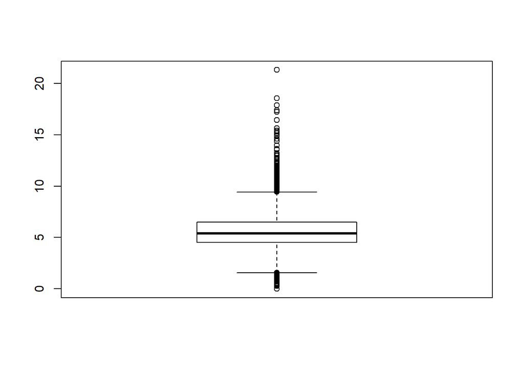

```r
boxplot(can_reg_omit$birth_rate)
```

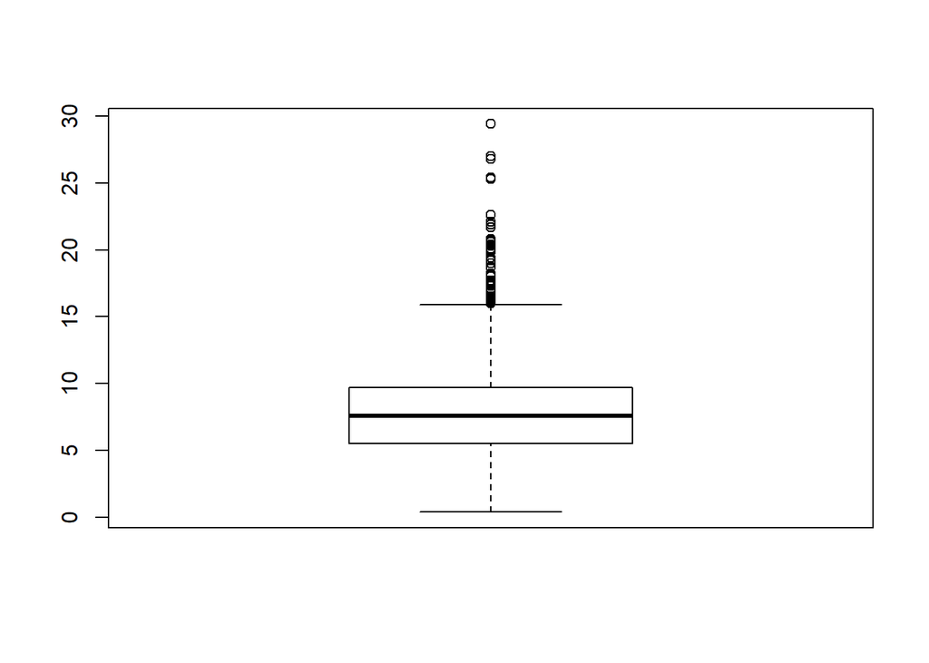

```r
boxplot(can_reg_omit$pct_unemployed16_over)
```

```r
forward1 = lm(formula = target_death_rate ~ pct_bach_deg25_over + incidence_rate + binned_inc + pct_married_households + pct_hs25_over + pct_unemployed16_over +
    median_age + birth_rate + pct_public_coverage_alone, data = can_reg_omit)


summary(forward1)
```

```
##
## Call:
## lm(formula = target_death_rate ~ pct_bach_deg25_over + incidence_rate +
##     binned_inc + pct_married_households + pct_hs25_over + pct_unemployed16_over +
##     median_age + birth_rate + pct_public_coverage_alone, data = can_reg_omit)
##
## Residuals:
##      Min       1Q   Median       3Q      Max
## -111.042  -11.462   -0.293   11.066  140.396
##
## Coefficients:
##                                Estimate Std. Error t value Pr(>|t|)
## (Intercept)                  112.126120   7.845545  14.292  < 2e-16 ***
## pct_bach_deg25_over           -1.116137   0.137871  -8.096 8.20e-16 ***
## incidence_rate                 0.201375   0.006904  29.167  < 2e-16 ***
## binned_inc(37413.8, 40362.7]  -2.612724   1.629046  -1.604 0.108855
## binned_inc(40362.7, 42724.4]  -5.061540   1.651120  -3.066 0.002192 **
## binned_inc(42724.4, 45201]    -6.146395   1.693373  -3.630 0.000289 ***
## binned_inc(45201, 48021.6]    -7.295396   1.736113  -4.202 2.72e-05 ***
## binned_inc(48021.6, 51046.4] -10.223190   1.792958  -5.702 1.30e-08 ***
## binned_inc(51046.4, 54545.6]  -9.561958   1.866020  -5.124 3.18e-07 ***
## binned_inc(54545.6, 61494.5]  -8.325071   1.946687  -4.277 1.96e-05 ***
## binned_inc(61494.5, 125635]   -5.461221   2.268135  -2.408 0.016109 *
## binned_inc[22640, 34218.1]     3.925258   1.667173   2.354 0.018615 *
## pct_married_households        -0.335068   0.073364  -4.567 5.14e-06 ***
## pct_hs25_over                  0.669633   0.086236   7.765 1.11e-14 ***
## pct_unemployed16_over          0.565714   0.148801   3.802 0.000146 ***
## median_age                    -0.408142   0.077398  -5.273 1.44e-07 ***
## birth_rate                    -0.706525   0.187735  -3.763 0.000171 ***
## pct_public_coverage_alone      0.325059   0.107884   3.013 0.002608 **
## ---
## Signif. codes:  0 '***' 0.001 '**' 0.01 '*' 0.05 '.' 0.1 ' ' 1
##
## Residual standard error: 19.73 on 2999 degrees of freedom
## Multiple R-squared:  0.4967, Adjusted R-squared:  0.4938
## F-statistic: 174.1 on 17 and 2999 DF,  p-value: < 2.2e-16
```

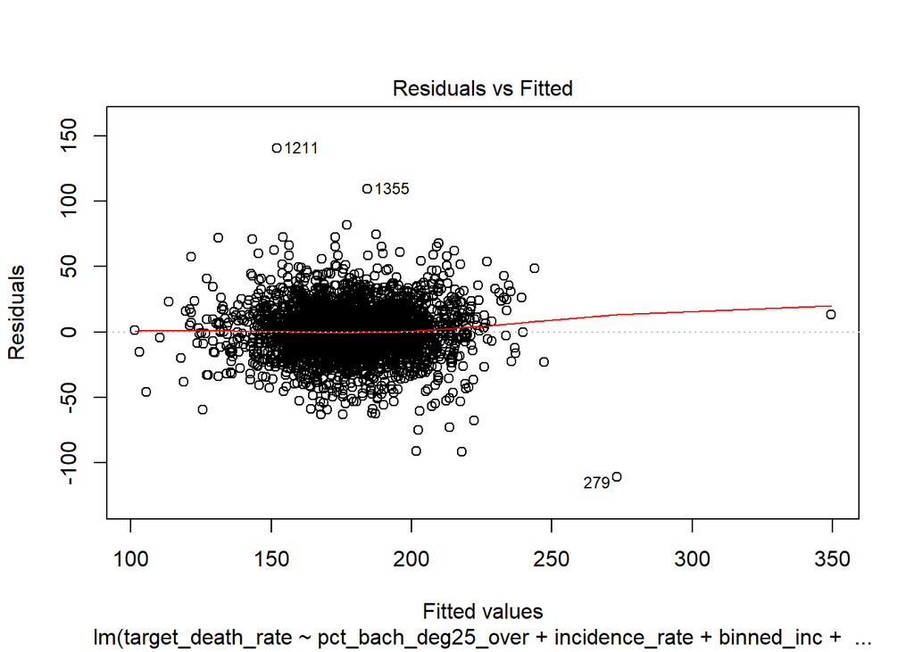

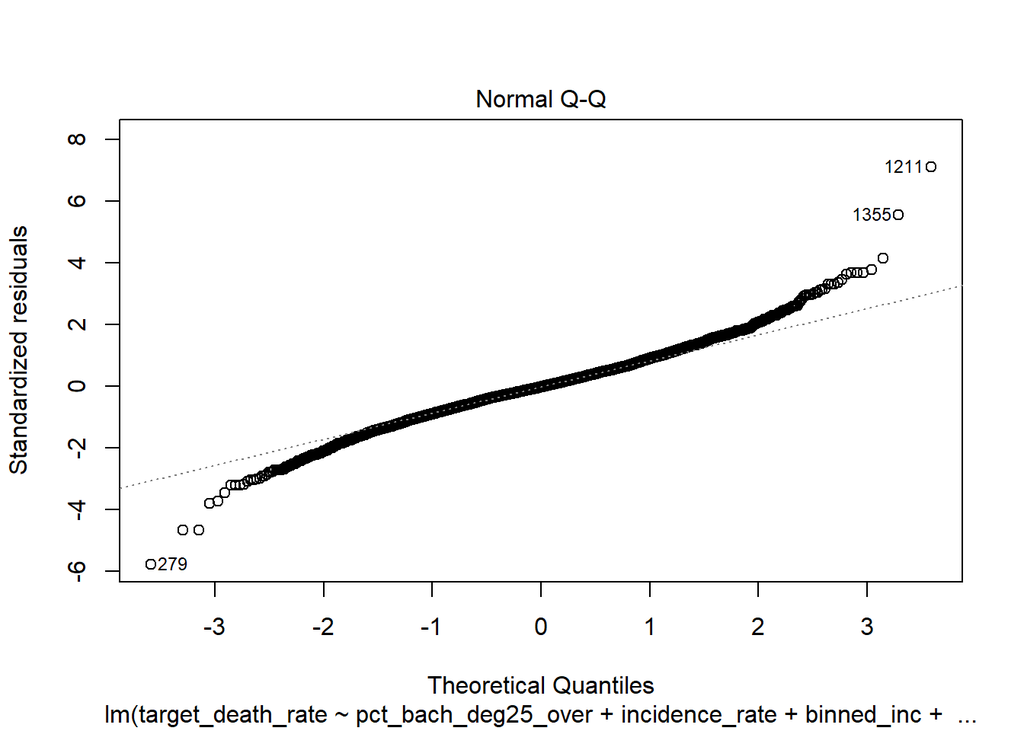

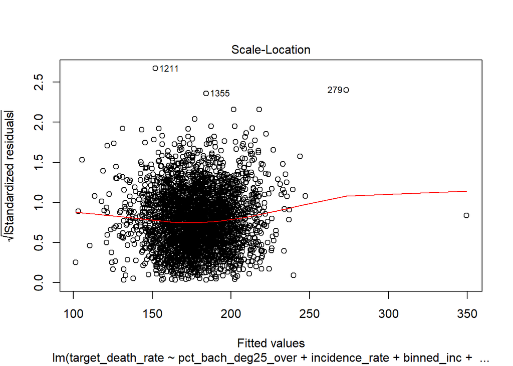

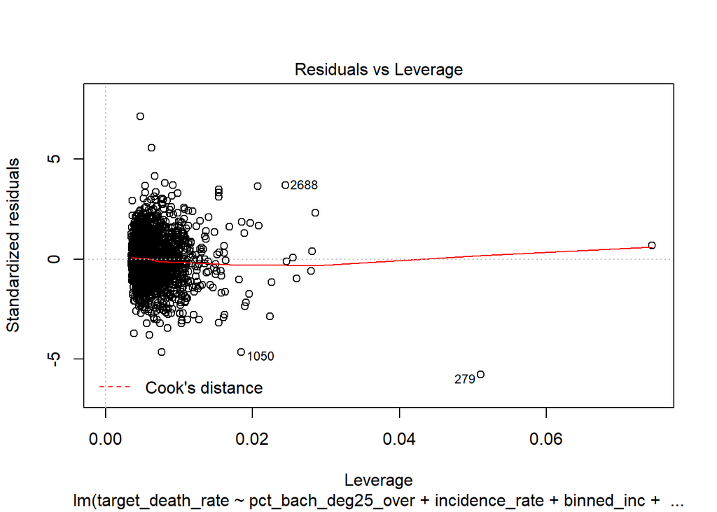

```r
plot(forward1)
```

Though global F test on this model tells us that the model coefficients are significant, Adjusted R-squared is only 0.4938. **we might need to consider further adjustment or other models to get better goodness of fit.**

Residuals V.S. Fitted : - outliers 1211, 1355, 279; - scattered around 0.

QQ plot: - straight line in the middle region; - when standardized residuals are small or large, there is a slight deviation. Slight deviation can be tolerated.

Scale-location: - generally in agreement with the Res VS Fitted plot;

Residuals VS leverage: - No point beyond the cook’s distance line

```r
#check multicolinearity
faraway::vif(forward1) %>% knitr::kable()
```

[output not shown]

```r
library(modelr)
library(mgcv)
```

```r
set.seed(1)

cv_forward1 =
  crossv_mc(can_reg_omit, 10) %>%
  mutate(train = map(train, as_tibble),
         test = map(test, as_tibble)) %>%
  mutate(model = map(train, ~lm(formula = target_death_rate ~ pct_bach_deg25_over + incidence_rate + binned_inc + pct_married_households + pct_hs25_over + pct_unemployed16_over + median_age + birth_rate + pct_public_coverage_alone, data = .x))) %>%
  mutate(mse = map2_dbl(model, test, ~mse(model = .x, data = .y)))


mean(cv_forward1$mse) #416.9129
```

```
## [1] 416.9129
```

```r
mse(model = forward1, data = can_reg_omit) #387.1092
```

```
## [1] 387.1092
```

The MSE of test data is close to the MSE of the original (training) data; percentage of difference is less than 10%.